# *Iris* flower data set

Camilo Marquez

# Introduction of the dataset

The *Iris* flower data set or *Fisher’s *Iris* data set* is a multivariate data set used and made famous by the British statistician and biologist [Ronald Fisher](https://en.wikipedia.org/wiki/Ronald_Fisher) in his 1936 paper *The use of multiple measurements in taxonomic problems* as an example of linear discriminant analysis. It is sometimes called Anderson’s *Iris* data set because Edgar Anderson collected the data to quantify the morphologic variation of Iris flowers of three related species.

Two of the three species were collected in the Gaspé Peninsula “all from the same pasture, and picked on the same day and measured at the same time by the same person with the same apparatus”. The data set consists of 50 samples from each of three species of Iris ([*Iris setosa*](https://en.wikipedia.org/wiki/Iris_setosa), [*Iris virginica*](https://en.wikipedia.org/wiki/Iris_virginica) and [*Iris versicolor*](https://en.wikipedia.org/wiki/Iris_versicolor)). Four features were measured from each sample: the length and the width of the sepals and petals, in centimeters. Based on the combination of these four features, Fisher developed a linear discriminant model to distinguish the species from each other. Fisher’s paper was published in the Annals of Eugenics and includes discussion of the contained techniques’ applications to the field of phrenology.

*Info taken from *[Wikipedia](https://en.wikipedia.org/wiki/Iris_flower_data_set)**

## Some nice pictures from the species

Species

Image

*Iris setosa*

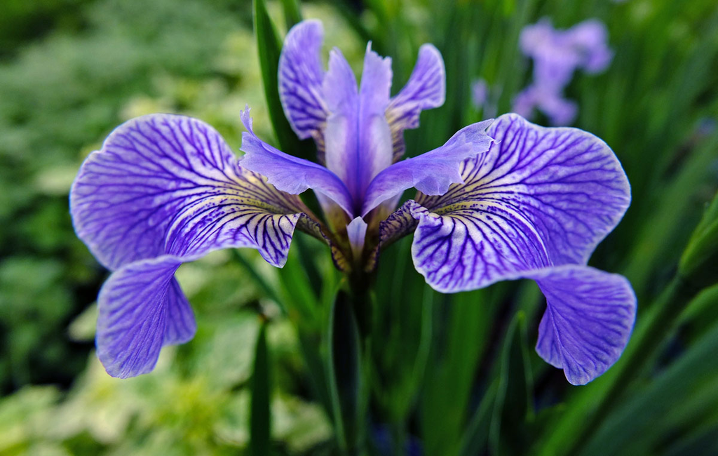

*Iris virginica*

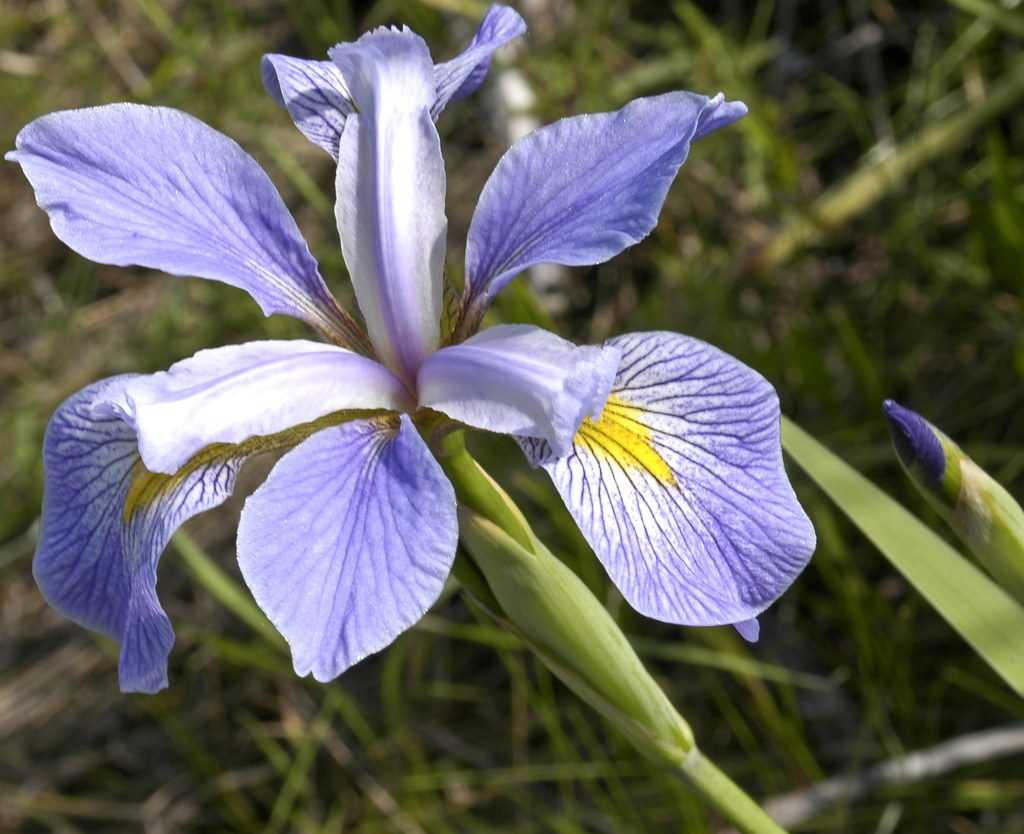

*Iris versicolor*

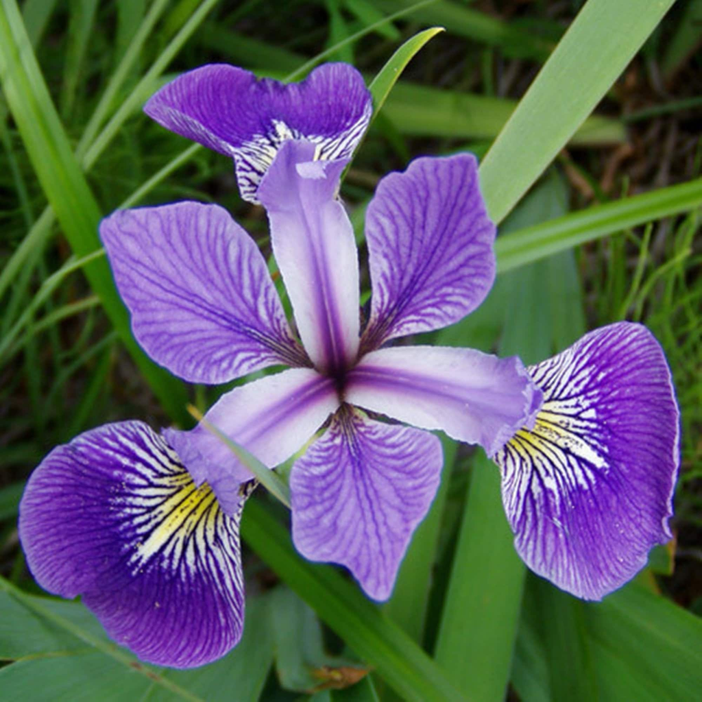

# Exploring *Iris* data in R

First, let’s take a look to the dataset:

```r
head(iris)
```

```
##   Sepal.Length Sepal.Width Petal.Length Petal.Width Species
## 1          5.1         3.5          1.4         0.2  setosa
## 2          4.9         3.0          1.4         0.2  setosa
## 3          4.7         3.2          1.3         0.2  setosa
## 4          4.6         3.1          1.5         0.2  setosa
## 5          5.0         3.6          1.4         0.2  setosa
## 6          5.4         3.9          1.7         0.4  setosa
```

The dataset is composed of 4 measurements of the 3 species of plants of the genus *Isris*, but surely you already know that :P

Now, some descriptive graphs

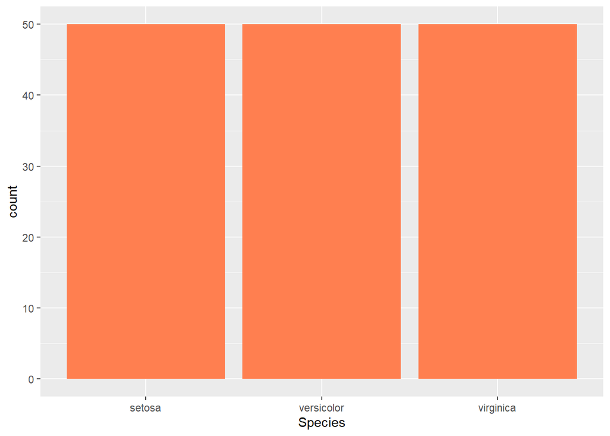

```r
library(ggplot2)
data(iris)
ggplot(data=iris, aes(x=Species))+geom_bar(fill="coral")
```

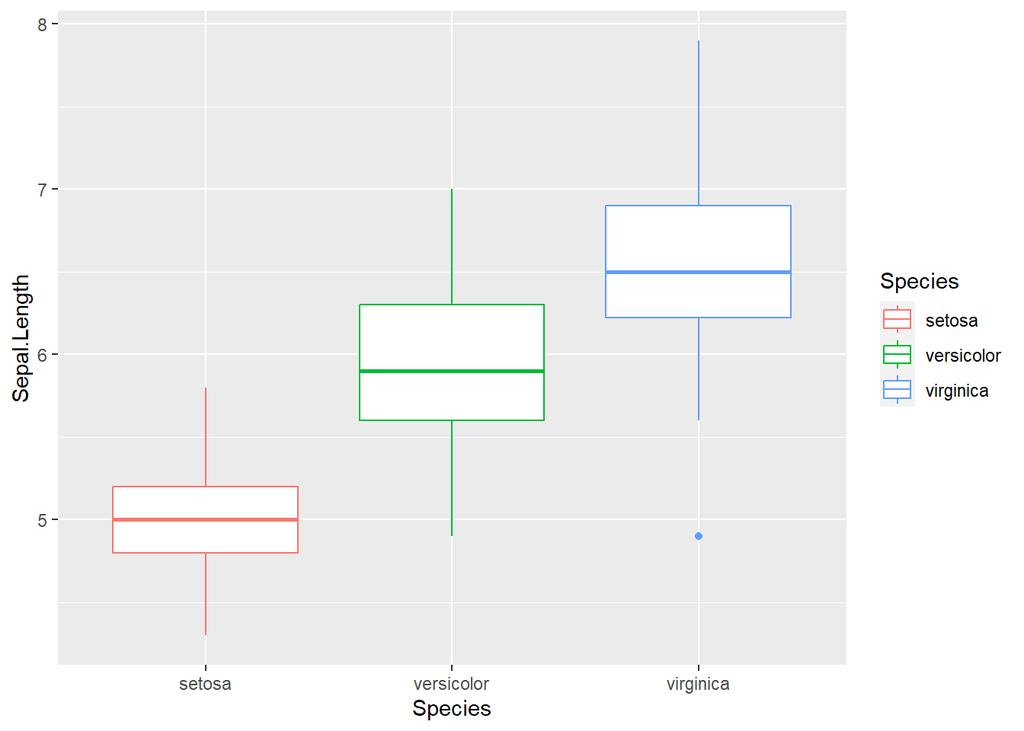

```r
ggplot(data = iris, aes(x=Species, y=Sepal.Length, color=Species))+
  geom_boxplot()
```

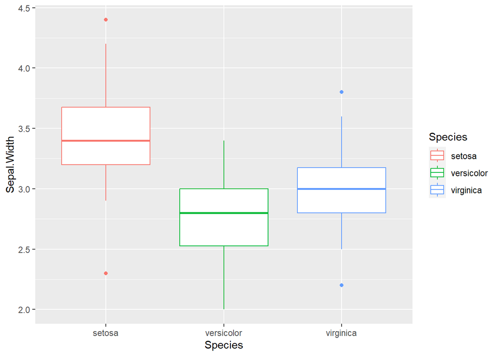

```r
ggplot(data = iris, aes(x=Species, y=Sepal.Width, color=Species))+
  geom_boxplot()
```

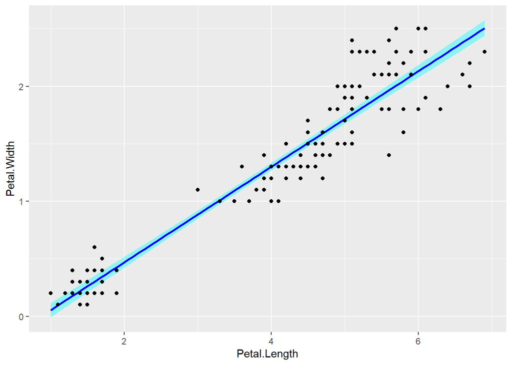

```r
ggplot(data=iris, aes(x=Petal.Length, y=Petal.Width))+
  geom_smooth(method = "lm",color="blue",fill="cyan")+
  geom_point()
```